# Tarea 6: Cálculo de probabilidades empíricas y comparación con teóricas

Andrea Santoyo

2025-03-02

A continuación se presentan una serie de ejercicios que debes resolver.

En el caso de las probabilidades empíricas genera por lo menos 100,000 simulaciones. La entrega final de esta actividad será un documento HTML con las respuestas a todas las preguntas. Para las probabilidades teóricas puedes escribir tus resultados en una hoja de tu cuaderno y agregarlas como imagen a tu documento HTML (es decir, no es necesario que desarrolles las ecuaciones en látex, dentro del RMD)

**Ejercicio 1**

La probabilidad de que el cambio en el precio de BIMBO sea negativo en los próximos 5 días. Para determinar los parámetros usa los datos del 01-feb-24 al 01-Feb-25. Estima la probabilidad empírica de dos maneras:

Calculo Empírico • Primero simula la ecuación St como lo hicimos en clase y calcula la probabilidad. • Segundo simula la ecuación ds en lugar de S y compara los resultados. Para simular ds, solo debes generar la cantidad de aleatorios necesarios para la simulación.

```r
library(quantmod)
library(lubridate)
clave <- "BIMBOA.MX"
datos <- new.env()
getSymbols(clave, from="2024-02-01", to="2025-02-01" ,env =datos) #año, mes, día
```

```
## [1] "BIMBOA.MX"
```

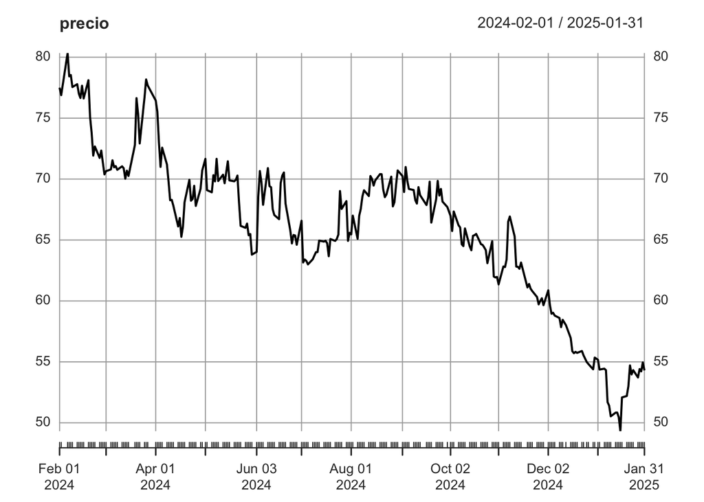

```r
precio <- datos[[clave]][,6]
plot(precio)
```

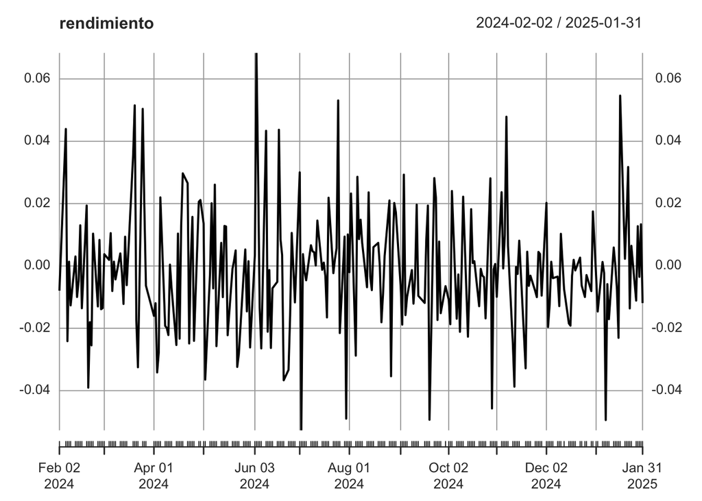

```r
rendimiento <- na.omit(diff(log(precio)))
plot(rendimiento)
```

# Cálculo st (empírico)

```r
rendimiento <- na.omit(diff(log(precio)))
mu_anual_hist <- mean(rendimiento)*252
sigma_anual_hist <- sd(rendimiento)*sqrt(252)
mu_anual_hist
```

```
## [1] -0.3586432
```

```r
sigma_anual_hist
```

```
## [1] 0.3095557
```

```r
set.seed(42)
So <- as.numeric(tail(precio,n=1))
mu <- -0.3586
sigma <- 0.3095
T <- 1
dt <- T/252
t <- seq(0,T,length.out=252)
```

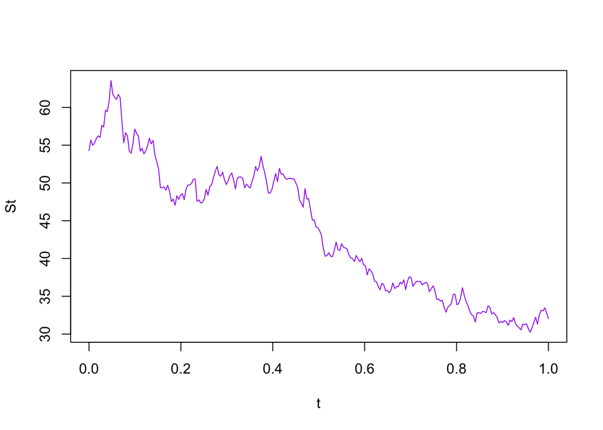

```r
W <- c(0,cumsum(sqrt(dt)*rnorm(251)))
St <- So*exp((mu-0.5*sigma^2)*t+sigma*W)
plot(t,St, type = "l", col="purple")
```

```r
sim <- 100000
p_final <- numeric(sim)

for (i in 1:sim) {
  W <- c(1,cumsum(sqrt(dt)*rnorm(251)))
  St <- So*exp((mu-0.5*sigma^2)*t+sigma*W)
  p_final[i] <- St[5]
}
```

[figure not shown]

```r
hist(p_final, n=100, col="darkgreen", main="Histograma para el precio en un año")
```

```r
mean(p_final < So)
```

```
## [1] 0.56603
```

# Cálculo ds (empírico)

```r
set.seed(42)
So <- as.numeric(tail(precio,n=1))
mu <- -0.3586
sigma <- 0.3095
T <- 5
dt <- T/252
dw <- sqrt(dt)*rnorm(sim)
ds <- So*mu*dt + So*sigma*dw

mean(ds < 0)
```

```
## [1] 0.56598
```

Cálculo teórico: • Usa tanto la ecuación Ln St como la ecuación ds para el cálculo de la probabilidad teórica. Compara los resultados obtenidos.

# Cálculo ln St (teórico)

```r
So
```

```
## [1] 54.3
```

```r
mu
```

```
## [1] -0.3586
```

```r
sigma
```

```
## [1] 0.3095
```

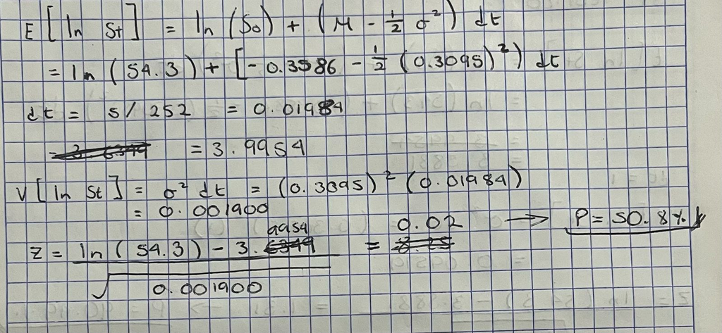

# Cálculo Ds (teórico)

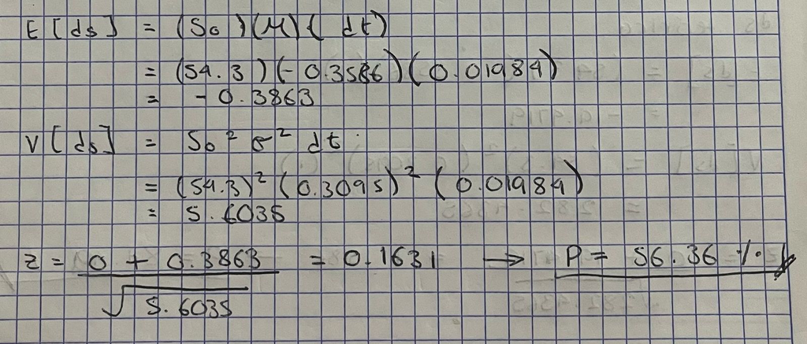

**Ejercicio 2**

Estima la misma probabilidad que la pregunta 1, pero ahora para dentro de un año.

# Cálculo st (empírico)

```r
set.seed(42)
So <- as.numeric(tail(precio,n=1))
mu <- -0.3586
sigma <- 0.3095
T <- 1
dt <- T/252
t <- seq(0,T,length.out=252)
```

```r
sim <- 100000
p_final <- numeric(sim)

for (i in 1:sim) {
  W <- c(1,cumsum(sqrt(dt)*rnorm(251)))
  St <- So*exp((mu-0.5*sigma^2)*t+sigma*W)
  p_final[i] <- St[252]
}

mean(p_final < So)
```

```
## [1] 0.90618
```

# Cálculo ds (empírico)

```r
set.seed(42)

dt <- 1
dw <- sqrt(dt)*rnorm(sim)
ds <- So*mu*dt + So*sigma*dw

mean(ds < 0)
```

```
## [1] 0.87662
```

# Cálculo ln St (teórico)

```r
So
```

```
## [1] 54.3
```

```r
mu
```

```
## [1] -0.3586
```

```r
sigma
```

```
## [1] 0.3095
```

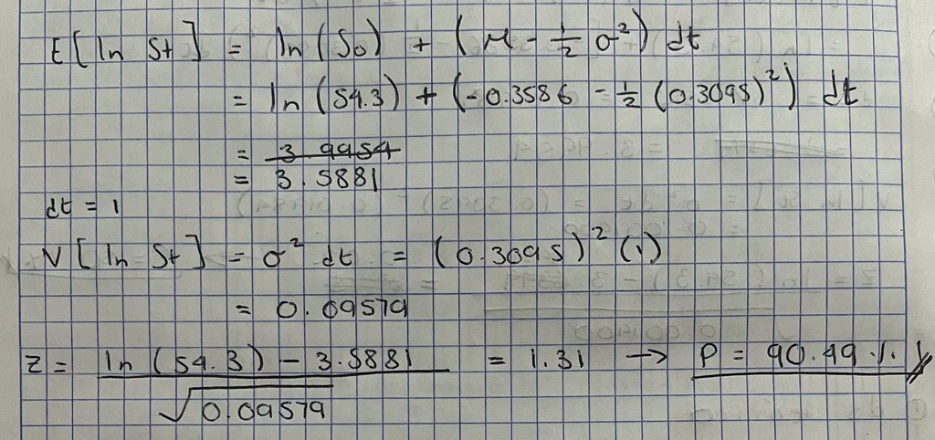

# Cálculo Ds (teórico)

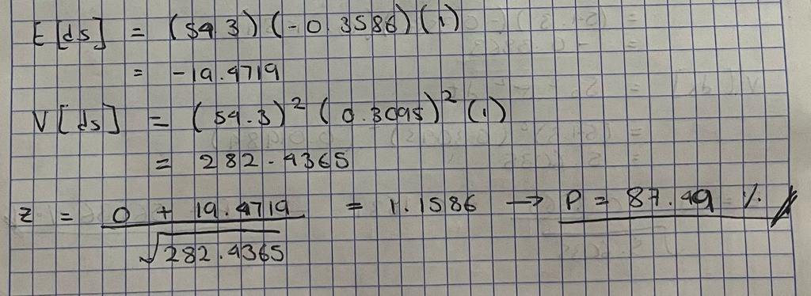

# Ejercicio 3

Analiza los resultados obtenidos tanto los ejercicios 1 y 2. ¿Qué puedes concluir sobre el uso de la ecuación ds o la ecuación ln St y St para calcular probabilidades?

# Ejercicio 4

Considera que el precio actual de un activo X, es de 15 y que tiene una media anual del 15% y volatilidad anual del 65%. Estima la probabilidad teórica y empírica de que el precio se mayor a 18 en 1 año, en seis meses y en un mes.

# 1 año: (empírico)

```r
set.seed(42)
So <- 15
mu <- 0.15
sigma <- 0.65
T <- 1
dt <- T/252
t <- seq(0,T,length.out=252)
```

```r
sim <- 100000
p_final <- numeric(sim)

for (i in 1:sim) {
  W <- c(1,cumsum(sqrt(dt)*rnorm(251)))
  St <- So*exp((mu-0.5*sigma^2)*t+sigma*W)
  p_final[i] <- St[252]
}

mean(p_final > 18)
```

```
## [1] 0.35452
```

# 6 meses: (empírico)

```r
set.seed(42)
So <- 15
mu <- 0.15
sigma <- 0.65
T <- 1
dt <- T/252
t <- seq(0,T,length.out=252)
```

```r
sim <- 100000
p_final <- numeric(sim)

for (i in 1:sim) {
  W <- c(1,cumsum(sqrt(dt)*rnorm(251)))
  St <- So*exp((mu-0.5*sigma^2)*t+sigma*W)
  p_final[i] <- St[252*0.5]
}

mean(p_final > 18)
```

```
## [1] 0.3217
```

# 1 mes empírico

```r
set.seed(42)
So <- 15
mu <- 0.15
sigma <- 0.65
T <- 1
dt <- T/252
t <- seq(0,T,length.out=252)
```

```r
sim <- 100000
p_final <- numeric(sim)

for (i in 1:sim) {
  W <- c(1,cumsum(sqrt(dt)*rnorm(251)))
  St <- So*exp((mu-0.5*sigma^2)*t+sigma*W)
  p_final[i] <- St[252/12]
}

mean(p_final > 18)
```

```
## [1] 0.15436
```

# teórico

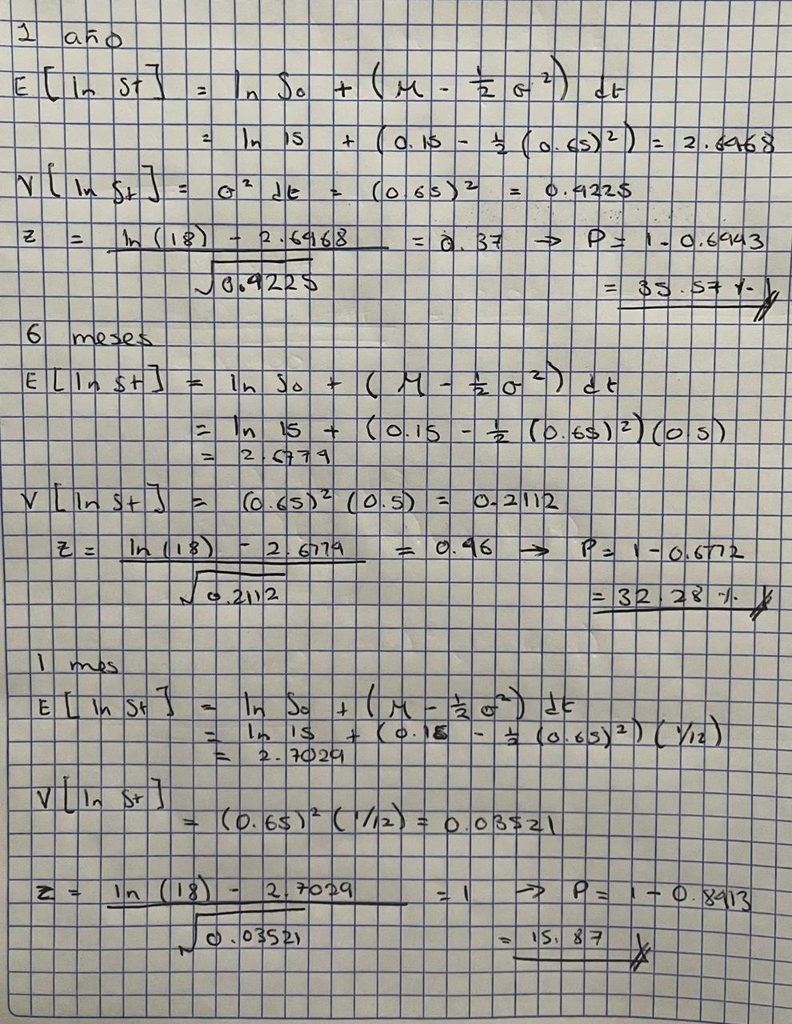

# Ejercicio 5

Modifica tu código de la pregunta 4 para que puedas calcular la misma probabilidad para valores de t, desde t=1, hasta t=240 (es decir 20 años). Efectúa una gráfica la probabilidad, donde en el eje vertical se vea el tiempo y en el horizontal la probabilidad. Describe la gráfica que obtuviste. ¿Qué puedes concluir sobre la relación que observas en la gráfica entre el tiempo y la probabilidad?

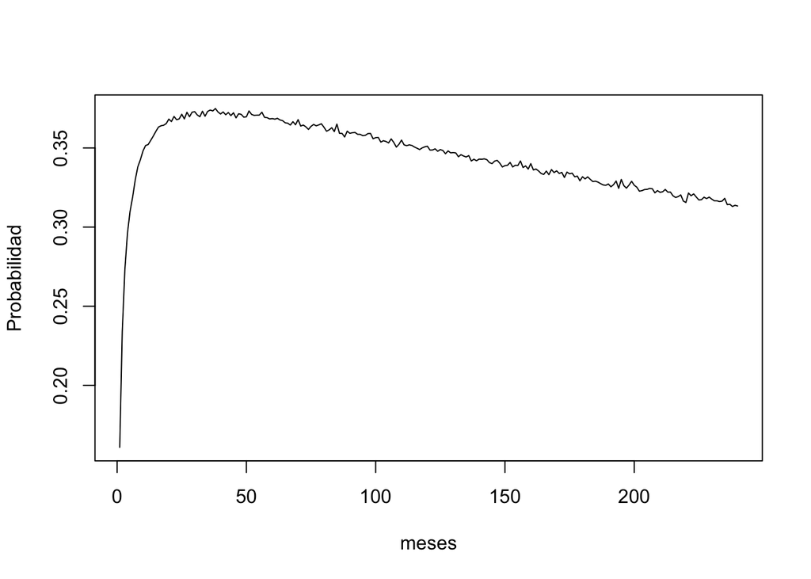

```r
prob <- numeric(240)

for (t in 1:240) {
  T <- t/12
  p_final <- numeric(sim)

  for (i in 1:sim) {
  St <- So*exp((mu-0.5*sigma^2)*T+sigma*sqrt(T)*rnorm(1))
  p_final[i] <- St
  }

prob[t] <- mean(p_final > 18)
}

plot(prob,
  type = "l",
  xlab = "meses",
  ylab = "Probabilidad",
)
```

De la gráfica podemos observar que mientras la T sea pequeña, la probabilidad de que S supere 18 va subiendo. Sin embargo, conforme avanza el tiempo y aumenta T vemos que esta probabilidad baja. Podemos ver que el punto máximo de la probabilidad es a los 30 meses aprox.